# Mathematical Optimisation 2021/2022 Vehicle rounting problem with load dependent travel times VRPLTT

## Trieste - 1

Utilizzando le api di Google Maps, è possibile ricavare una matrice delle distanze e le elevazioni di una serie di punti.

[figure not shown]

## Trieste - 2

Abbiamo quindi generato un’istanza scegliendo dei punti nella città di Trieste e visualizzato i subtour delle soluzioni ottenute.

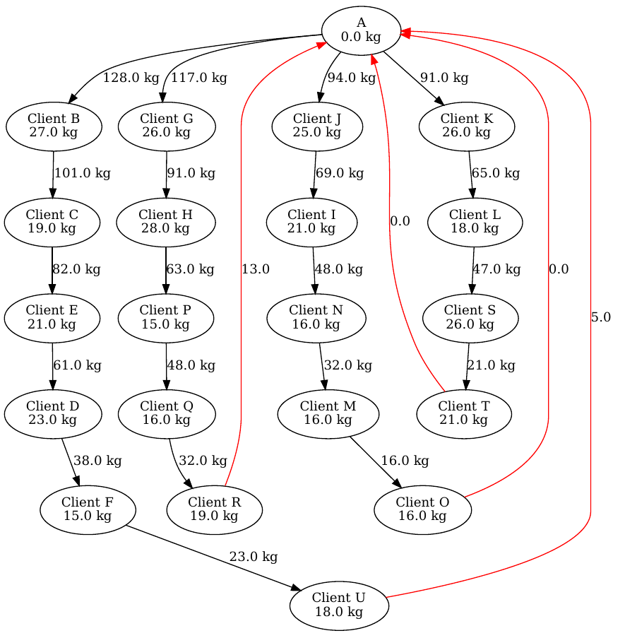

[figure not shown]

## Conclusioni

- I risultati degli esperimenti numerici confermano l’importanza di includere i dettagli sull’elevazione del percorso tra due nodi. Il valore della funzione obiettivo varia molto nei due casi. Il valore senza punti intermedi risulta in generale sottostimato.

Possibili linee di miglioramento:

- Un altro possibile miglioramento è l’inserimento di tempi di percorrenza che tengano conto dei transitori e non della sola velocità all’equilibrio. Lo svantaggio è più evidente nelle salite con accelerazioni minori.
- Potrebbe essere inserito un vincolo sull’energia totale disponibile, dal punto di vista del mezzo elettrico e del conducente.